# Risk Factor Analysis

## Outcome Variable

**Outcome Variable:** y_rate_haz

## Predictor Variables

**Intervention Variable:** safeh20

**Adjustment Set:**

unadjusted

## Stratifying Variables

The analysis was stratified on these variable(s):

- agecat
- studyid
- country

## Data Summary

| agecat | studyid | country | safeh20 | n_cell | n |
| --- | --- | --- | --- | --- | --- |
| 0-3 months | ki0047075b-MAL-ED | BANGLADESH | 0 | 237 | 237 |
| 0-3 months | ki1017093-NIH-Birth | BANGLADESH | 0 | 2 | 566 |
| 0-3 months | ki1017093-NIH-Birth | BANGLADESH | 1 | 564 | 566 |
| 0-3 months | ki1017093b-PROVIDE | BANGLADESH | 1 | 634 | 634 |
| 0-3 months | ki1017093c-NIH-Crypto | BANGLADESH | 1 | 720 | 720 |
| 0-3 months | kiGH5241-JiVitA-3 | BANGLADESH | 0 | 35 | 20029 |
| 0-3 months | kiGH5241-JiVitA-3 | BANGLADESH | 1 | 19994 | 20029 |
| 0-3 months | kiGH5241-JiVitA-4 | BANGLADESH | 1 | 1805 | 1805 |
| 0-3 months | ki0047075b-MAL-ED | BRAZIL | 0 | 124 | 124 |
| 0-3 months | ki0047075b-MAL-ED | INDIA | 0 | 194 | 194 |
| 0-3 months | ki0047075b-MAL-ED | NEPAL | 0 | 170 | 171 |
| 0-3 months | ki0047075b-MAL-ED | NEPAL | 1 | 1 | 171 |
| 0-3 months | ki0047075b-MAL-ED | PERU | 0 | 238 | 249 |
| 0-3 months | ki0047075b-MAL-ED | PERU | 1 | 11 | 249 |
| 0-3 months | ki1114097-CONTENT | PERU | 0 | 1 | 6 |
| 0-3 months | ki1114097-CONTENT | PERU | 1 | 5 | 6 |
| 0-3 months | ki0047075b-MAL-ED | SOUTH AFRICA | 0 | 180 | 213 |
| 0-3 months | ki0047075b-MAL-ED | SOUTH AFRICA | 1 | 33 | 213 |
| 0-3 months | ki0047075b-MAL-ED | TANZANIA, UNITED REPUBLIC OF | 0 | 70 | 225 |
| 0-3 months | ki0047075b-MAL-ED | TANZANIA, UNITED REPUBLIC OF | 1 | 155 | 225 |
| 3-6 months | ki0047075b-MAL-ED | BANGLADESH | 0 | 231 | 231 |
| 3-6 months | ki1017093-NIH-Birth | BANGLADESH | 0 | 2 | 523 |
| 3-6 months | ki1017093-NIH-Birth | BANGLADESH | 1 | 521 | 523 |
| 3-6 months | ki1017093b-PROVIDE | BANGLADESH | 1 | 572 | 572 |
| 3-6 months | ki1017093c-NIH-Crypto | BANGLADESH | 1 | 695 | 695 |
| 3-6 months | kiGH5241-JiVitA-3 | BANGLADESH | 0 | 12 | 12573 |
| 3-6 months | kiGH5241-JiVitA-3 | BANGLADESH | 1 | 12561 | 12573 |
| 3-6 months | kiGH5241-JiVitA-4 | BANGLADESH | 1 | 1839 | 1839 |
| 3-6 months | ki0047075b-MAL-ED | BRAZIL | 0 | 141 | 141 |
| 3-6 months | ki0047075b-MAL-ED | INDIA | 0 | 229 | 229 |

[output cut: 55 more lines]

The following strata were considered:

- agecat: 0-3 months, studyid: ki0047075b-MAL-ED, country: BANGLADESH
- agecat: 0-3 months, studyid: ki0047075b-MAL-ED, country: BRAZIL
- agecat: 0-3 months, studyid: ki0047075b-MAL-ED, country: INDIA
- agecat: 0-3 months, studyid: ki0047075b-MAL-ED, country: NEPAL
- agecat: 0-3 months, studyid: ki0047075b-MAL-ED, country: PERU
- agecat: 0-3 months, studyid: ki0047075b-MAL-ED, country: SOUTH AFRICA
- agecat: 0-3 months, studyid: ki0047075b-MAL-ED, country: TANZANIA, UNITED REPUBLIC OF
- agecat: 0-3 months, studyid: ki1017093-NIH-Birth, country: BANGLADESH
- agecat: 0-3 months, studyid: ki1017093b-PROVIDE, country: BANGLADESH
- agecat: 0-3 months, studyid: ki1017093c-NIH-Crypto, country: BANGLADESH
- agecat: 0-3 months, studyid: ki1114097-CONTENT, country: PERU
- agecat: 0-3 months, studyid: kiGH5241-JiVitA-3, country: BANGLADESH
- agecat: 0-3 months, studyid: kiGH5241-JiVitA-4, country: BANGLADESH
- agecat: 12-24 months, studyid: ki0047075b-MAL-ED, country: BANGLADESH
- agecat: 12-24 months, studyid: ki0047075b-MAL-ED, country: BRAZIL
- agecat: 12-24 months, studyid: ki0047075b-MAL-ED, country: INDIA
- agecat: 12-24 months, studyid: ki0047075b-MAL-ED, country: NEPAL
- agecat: 12-24 months, studyid: ki0047075b-MAL-ED, country: PERU
- agecat: 12-24 months, studyid: ki0047075b-MAL-ED, country: SOUTH AFRICA
- agecat: 12-24 months, studyid: ki0047075b-MAL-ED, country: TANZANIA, UNITED REPUBLIC OF
- agecat: 12-24 months, studyid: ki1017093-NIH-Birth, country: BANGLADESH
- agecat: 12-24 months, studyid: ki1017093b-PROVIDE, country: BANGLADESH
- agecat: 12-24 months, studyid: ki1017093c-NIH-Crypto, country: BANGLADESH
- agecat: 12-24 months, studyid: ki1114097-CONTENT, country: PERU
- agecat: 12-24 months, studyid: ki1148112-LCNI-5, country: MALAWI
- agecat: 12-24 months, studyid: kiGH5241-JiVitA-3, country: BANGLADESH
- agecat: 12-24 months, studyid: kiGH5241-JiVitA-4, country: BANGLADESH
- agecat: 3-6 months, studyid: ki0047075b-MAL-ED, country: BANGLADESH
- agecat: 3-6 months, studyid: ki0047075b-MAL-ED, country: BRAZIL
- agecat: 3-6 months, studyid: ki0047075b-MAL-ED, country: INDIA
- agecat: 3-6 months, studyid: ki0047075b-MAL-ED, country: NEPAL
- agecat: 3-6 months, studyid: ki0047075b-MAL-ED, country: PERU
- agecat: 3-6 months, studyid: ki0047075b-MAL-ED, country: SOUTH AFRICA
- agecat: 3-6 months, studyid: ki0047075b-MAL-ED, country: TANZANIA, UNITED REPUBLIC OF
- agecat: 3-6 months, studyid: ki1017093-NIH-Birth, country: BANGLADESH
- agecat: 3-6 months, studyid: ki1017093b-PROVIDE, country: BANGLADESH
- agecat: 3-6 months, studyid: ki1017093c-NIH-Crypto, country: BANGLADESH
- agecat: 3-6 months, studyid: ki1114097-CONTENT, country: PERU
- agecat: 3-6 months, studyid: kiGH5241-JiVitA-3, country: BANGLADESH
- agecat: 3-6 months, studyid: kiGH5241-JiVitA-4, country: BANGLADESH
- agecat: 6-12 months, studyid: ki0047075b-MAL-ED, country: BANGLADESH
- agecat: 6-12 months, studyid: ki0047075b-MAL-ED, country: BRAZIL
- agecat: 6-12 months, studyid: ki0047075b-MAL-ED, country: INDIA
- agecat: 6-12 months, studyid: ki0047075b-MAL-ED, country: NEPAL
- agecat: 6-12 months, studyid: ki0047075b-MAL-ED, country: PERU
- agecat: 6-12 months, studyid: ki0047075b-MAL-ED, country: SOUTH AFRICA
- agecat: 6-12 months, studyid: ki0047075b-MAL-ED, country: TANZANIA, UNITED REPUBLIC OF
- agecat: 6-12 months, studyid: ki1000304b-SAS-FoodSuppl, country: INDIA
- agecat: 6-12 months, studyid: ki1017093-NIH-Birth, country: BANGLADESH
- agecat: 6-12 months, studyid: ki1017093b-PROVIDE, country: BANGLADESH
- agecat: 6-12 months, studyid: ki1017093c-NIH-Crypto, country: BANGLADESH
- agecat: 6-12 months, studyid: ki1114097-CONTENT, country: PERU
- agecat: 6-12 months, studyid: ki1148112-LCNI-5, country: MALAWI
- agecat: 6-12 months, studyid: kiGH5241-JiVitA-3, country: BANGLADESH
- agecat: 6-12 months, studyid: kiGH5241-JiVitA-4, country: BANGLADESH

### Dropped Strata

Some strata were dropped due to rare outcomes:

- agecat: 0-3 months, studyid: ki1017093-NIH-Birth, country: BANGLADESH
- agecat: 0-3 months, studyid: ki0047075b-MAL-ED, country: NEPAL
- agecat: 0-3 months, studyid: ki1114097-CONTENT, country: PERU
- agecat: 3-6 months, studyid: ki1017093-NIH-Birth, country: BANGLADESH
- agecat: 3-6 months, studyid: ki0047075b-MAL-ED, country: NEPAL
- agecat: 3-6 months, studyid: ki1114097-CONTENT, country: PERU
- agecat: 6-12 months, studyid: ki1017093-NIH-Birth, country: BANGLADESH
- agecat: 6-12 months, studyid: ki0047075b-MAL-ED, country: NEPAL
- agecat: 6-12 months, studyid: ki1114097-CONTENT, country: PERU
- agecat: 12-24 months, studyid: ki1017093-NIH-Birth, country: BANGLADESH
- agecat: 12-24 months, studyid: ki0047075b-MAL-ED, country: NEPAL
- agecat: 12-24 months, studyid: ki1114097-CONTENT, country: PERU

## Methods Detail

We’re interested in the causal parameters $E[Y_a]$ for all values of $a \in \mathcal{A}$. These parameters represent the mean outcome if, possibly contrary to fact, we intervened to set all units to have $A=a$. Under the randomization and positivity assumptions, these are identified by the statistical parameters $\psi_a=E_W[E_{Y|A,W}(Y|A=a,W)]$. In addition, we’re interested in the mean of $Y$, $E[Y]$ under no intervention (the observed mean). We will estimate these parameters by using SuperLearner to fit the relevant likelihood factors – $E_{Y|A,W}(Y|A=a,W)$ and $p(A=a|W)$, and then updating our likelihood fit using a joint TMLE.

For unadjusted analyses ($W=\{\}$), initial likelihoods were estimated using Lrnr_glm to estimate the simple $E(Y|A)$ and Lrnr_mean to estimate $p(A)$. For adjusted analyses, a small library containing Lrnr_glmnet, Lrnr_xgboost, and Lrnr_mean was used.

[output not shown]

[output cut: 18485 more lines]

[output not shown]

# Results Detail

## Results Plots

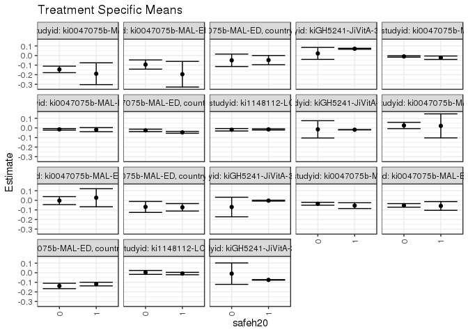

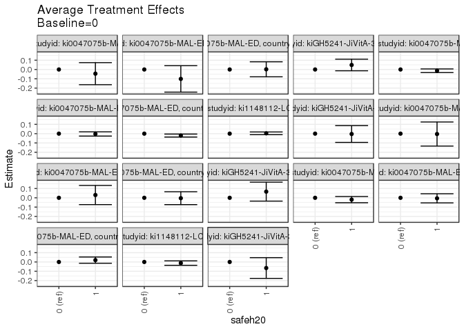

## Results Table

### Parameter: TSM

| agecat | studyid | country | intervention_level | baseline_level | estimate | ci_lower | ci_upper |
| --- | --- | --- | --- | --- | --- | --- | --- |
| 0-3 months | ki0047075b-MAL-ED | PERU | 0 | NA | -0.1448464 | -0.1787280 | -0.1109649 |
| 0-3 months | ki0047075b-MAL-ED | PERU | 1 | NA | -0.1897295 | -0.3034704 | -0.0759886 |
| 0-3 months | ki0047075b-MAL-ED | SOUTH AFRICA | 0 | NA | -0.0937500 | -0.1419918 | -0.0455082 |
| 0-3 months | ki0047075b-MAL-ED | SOUTH AFRICA | 1 | NA | -0.1948561 | -0.3285230 | -0.0611892 |
| 0-3 months | ki0047075b-MAL-ED | TANZANIA, UNITED REPUBLIC OF | 0 | NA | -0.0497005 | -0.1146377 | 0.0152367 |
| 0-3 months | ki0047075b-MAL-ED | TANZANIA, UNITED REPUBLIC OF | 1 | NA | -0.0475989 | -0.0955558 | 0.0003580 |
| 0-3 months | kiGH5241-JiVitA-3 | BANGLADESH | 0 | NA | 0.0220333 | -0.0403936 | 0.0844602 |
| 0-3 months | kiGH5241-JiVitA-3 | BANGLADESH | 1 | NA | 0.0706472 | 0.0656896 | 0.0756047 |
| 3-6 months | ki0047075b-MAL-ED | PERU | 0 | NA | 0.0255127 | -0.0072851 | 0.0583106 |
| 3-6 months | ki0047075b-MAL-ED | PERU | 1 | NA | 0.0214805 | -0.1038637 | 0.1468247 |
| 3-6 months | ki0047075b-MAL-ED | SOUTH AFRICA | 0 | NA | -0.0029341 | -0.0446100 | 0.0387417 |
| 3-6 months | ki0047075b-MAL-ED | SOUTH AFRICA | 1 | NA | 0.0271555 | -0.0671636 | 0.1214745 |
| 3-6 months | ki0047075b-MAL-ED | TANZANIA, UNITED REPUBLIC OF | 0 | NA | -0.0687704 | -0.1260899 | -0.0114510 |
| 3-6 months | ki0047075b-MAL-ED | TANZANIA, UNITED REPUBLIC OF | 1 | NA | -0.0727068 | -0.1117404 | -0.0336732 |
| 3-6 months | kiGH5241-JiVitA-3 | BANGLADESH | 0 | NA | -0.0698670 | -0.1718748 | 0.0321408 |
| 3-6 months | kiGH5241-JiVitA-3 | BANGLADESH | 1 | NA | -0.0033811 | -0.0082452 | 0.0014830 |
| 6-12 months | ki0047075b-MAL-ED | PERU | 0 | NA | -0.0357437 | -0.0507991 | -0.0206882 |
| 6-12 months | ki0047075b-MAL-ED | PERU | 1 | NA | -0.0552980 | -0.0851806 | -0.0254155 |
| 6-12 months | ki0047075b-MAL-ED | SOUTH AFRICA | 0 | NA | -0.0528871 | -0.0717299 | -0.0340443 |
| 6-12 months | ki0047075b-MAL-ED | SOUTH AFRICA | 1 | NA | -0.0584244 | -0.1039856 | -0.0128632 |
| 6-12 months | ki0047075b-MAL-ED | TANZANIA, UNITED REPUBLIC OF | 0 | NA | -0.1380919 | -0.1661525 | -0.1100312 |
| 6-12 months | ki0047075b-MAL-ED | TANZANIA, UNITED REPUBLIC OF | 1 | NA | -0.1182938 | -0.1371754 | -0.0994123 |
| 6-12 months | ki1148112-LCNI-5 | MALAWI | 0 | NA | 0.0032895 | -0.0171204 | 0.0236995 |
| 6-12 months | ki1148112-LCNI-5 | MALAWI | 1 | NA | -0.0087544 | -0.0212444 | 0.0037356 |
| 6-12 months | kiGH5241-JiVitA-3 | BANGLADESH | 0 | NA | -0.0096573 | -0.1212098 | 0.1018951 |
| 6-12 months | kiGH5241-JiVitA-3 | BANGLADESH | 1 | NA | -0.0749128 | -0.0777564 | -0.0720693 |
| 12-24 months | ki0047075b-MAL-ED | PERU | 0 | NA | -0.0094516 | -0.0168890 | -0.0020142 |
| 12-24 months | ki0047075b-MAL-ED | PERU | 1 | NA | -0.0230515 | -0.0411666 | -0.0049364 |
| 12-24 months | ki0047075b-MAL-ED | SOUTH AFRICA | 0 | NA | -0.0150790 | -0.0231875 | -0.0069705 |
| 12-24 months | ki0047075b-MAL-ED | SOUTH AFRICA | 1 | NA | -0.0182451 | -0.0397254 | 0.0032353 |
| 12-24 months | ki0047075b-MAL-ED | TANZANIA, UNITED REPUBLIC OF | 0 | NA | -0.0258118 | -0.0388183 | -0.0128053 |
| 12-24 months | ki0047075b-MAL-ED | TANZANIA, UNITED REPUBLIC OF | 1 | NA | -0.0462183 | -0.0556783 | -0.0367584 |
| 12-24 months | ki1148112-LCNI-5 | MALAWI | 0 | NA | -0.0190768 | -0.0321017 | -0.0060520 |
| 12-24 months | ki1148112-LCNI-5 | MALAWI | 1 | NA | -0.0155015 | -0.0219504 | -0.0090526 |
| 12-24 months | kiGH5241-JiVitA-3 | BANGLADESH | 0 | NA | -0.0149649 | -0.1055295 | 0.0755997 |
| 12-24 months | kiGH5241-JiVitA-3 | BANGLADESH | 1 | NA | -0.0187844 | -0.0206252 | -0.0169437 |

### Parameter: E(Y)

| agecat | studyid | country | intervention_level | baseline_level | estimate | ci_lower | ci_upper |
| --- | --- | --- | --- | --- | --- | --- | --- |
| 0-3 months | ki0047075b-MAL-ED | PERU | NA | NA | -0.1468292 | -0.1796215 | -0.1140369 |
| 0-3 months | ki0047075b-MAL-ED | SOUTH AFRICA | NA | NA | -0.1094143 | -0.1554047 | -0.0634239 |
| 0-3 months | ki0047075b-MAL-ED | TANZANIA, UNITED REPUBLIC OF | NA | NA | -0.0482527 | -0.0869775 | -0.0095280 |
| 0-3 months | kiGH5241-JiVitA-3 | BANGLADESH | NA | NA | 0.0705622 | 0.0656080 | 0.0755165 |
| 3-6 months | ki0047075b-MAL-ED | PERU | NA | NA | 0.0253395 | -0.0065080 | 0.0571869 |
| 3-6 months | ki0047075b-MAL-ED | SOUTH AFRICA | NA | NA | 0.0016172 | -0.0365482 | 0.0397826 |
| 3-6 months | ki0047075b-MAL-ED | TANZANIA, UNITED REPUBLIC OF | NA | NA | -0.0714664 | -0.1037306 | -0.0392021 |
| 3-6 months | kiGH5241-JiVitA-3 | BANGLADESH | NA | NA | -0.0034446 | -0.0083108 | 0.0014217 |
| 6-12 months | ki0047075b-MAL-ED | PERU | NA | NA | -0.0365155 | -0.0510332 | -0.0219979 |
| 6-12 months | ki0047075b-MAL-ED | SOUTH AFRICA | NA | NA | -0.0537261 | -0.0711424 | -0.0363097 |
| 6-12 months | ki0047075b-MAL-ED | TANZANIA, UNITED REPUBLIC OF | NA | NA | -0.1243581 | -0.1400706 | -0.1086456 |
| 6-12 months | ki1148112-LCNI-5 | MALAWI | NA | NA | -0.0067938 | -0.0177737 | 0.0041862 |
| 6-12 months | kiGH5241-JiVitA-3 | BANGLADESH | NA | NA | -0.0748465 | -0.0776904 | -0.0720026 |
| 12-24 months | ki0047075b-MAL-ED | PERU | NA | NA | -0.0099718 | -0.0171682 | -0.0027754 |
| 12-24 months | ki0047075b-MAL-ED | SOUTH AFRICA | NA | NA | -0.0155353 | -0.0231357 | -0.0079349 |
| 12-24 months | ki0047075b-MAL-ED | TANZANIA, UNITED REPUBLIC OF | NA | NA | -0.0398784 | -0.0476581 | -0.0320988 |
| 12-24 months | ki1148112-LCNI-5 | MALAWI | NA | NA | -0.0160605 | -0.0218715 | -0.0102495 |
| 12-24 months | kiGH5241-JiVitA-3 | BANGLADESH | NA | NA | -0.0187787 | -0.0206287 | -0.0169287 |

### Parameter: ATE

| agecat | studyid | country | intervention_level | baseline_level | estimate | ci_lower | ci_upper |
| --- | --- | --- | --- | --- | --- | --- | --- |
| 0-3 months | ki0047075b-MAL-ED | PERU | 0 | 0 | 0.0000000 | 0.0000000 | 0.0000000 |
| 0-3 months | ki0047075b-MAL-ED | PERU | 1 | 0 | -0.0448831 | -0.1635631 | 0.0737969 |
| 0-3 months | ki0047075b-MAL-ED | SOUTH AFRICA | 0 | 0 | 0.0000000 | 0.0000000 | 0.0000000 |
| 0-3 months | ki0047075b-MAL-ED | SOUTH AFRICA | 1 | 0 | -0.1011061 | -0.2432121 | 0.0409999 |
| 0-3 months | ki0047075b-MAL-ED | TANZANIA, UNITED REPUBLIC OF | 0 | 0 | 0.0000000 | 0.0000000 | 0.0000000 |
| 0-3 months | ki0047075b-MAL-ED | TANZANIA, UNITED REPUBLIC OF | 1 | 0 | 0.0021016 | -0.0786245 | 0.0828277 |
| 0-3 months | kiGH5241-JiVitA-3 | BANGLADESH | 0 | 0 | 0.0000000 | 0.0000000 | 0.0000000 |
| 0-3 months | kiGH5241-JiVitA-3 | BANGLADESH | 1 | 0 | 0.0486139 | -0.0137063 | 0.1109341 |
| 3-6 months | ki0047075b-MAL-ED | PERU | 0 | 0 | 0.0000000 | 0.0000000 | 0.0000000 |
| 3-6 months | ki0047075b-MAL-ED | PERU | 1 | 0 | -0.0040322 | -0.1335964 | 0.1255319 |
| 3-6 months | ki0047075b-MAL-ED | SOUTH AFRICA | 0 | 0 | 0.0000000 | 0.0000000 | 0.0000000 |
| 3-6 months | ki0047075b-MAL-ED | SOUTH AFRICA | 1 | 0 | 0.0300896 | -0.0730266 | 0.1332058 |
| 3-6 months | ki0047075b-MAL-ED | TANZANIA, UNITED REPUBLIC OF | 0 | 0 | 0.0000000 | 0.0000000 | 0.0000000 |
| 3-6 months | ki0047075b-MAL-ED | TANZANIA, UNITED REPUBLIC OF | 1 | 0 | -0.0039364 | -0.0732844 | 0.0654116 |
| 3-6 months | kiGH5241-JiVitA-3 | BANGLADESH | 0 | 0 | 0.0000000 | 0.0000000 | 0.0000000 |
| 3-6 months | kiGH5241-JiVitA-3 | BANGLADESH | 1 | 0 | 0.0664859 | -0.0352994 | 0.1682712 |
| 6-12 months | ki0047075b-MAL-ED | PERU | 0 | 0 | 0.0000000 | 0.0000000 | 0.0000000 |
| 6-12 months | ki0047075b-MAL-ED | PERU | 1 | 0 | -0.0195544 | -0.0530153 | 0.0139065 |
| 6-12 months | ki0047075b-MAL-ED | SOUTH AFRICA | 0 | 0 | 0.0000000 | 0.0000000 | 0.0000000 |
| 6-12 months | ki0047075b-MAL-ED | SOUTH AFRICA | 1 | 0 | -0.0055373 | -0.0548413 | 0.0437666 |
| 6-12 months | ki0047075b-MAL-ED | TANZANIA, UNITED REPUBLIC OF | 0 | 0 | 0.0000000 | 0.0000000 | 0.0000000 |
| 6-12 months | ki0047075b-MAL-ED | TANZANIA, UNITED REPUBLIC OF | 1 | 0 | 0.0197980 | -0.0140237 | 0.0536198 |
| 6-12 months | ki1148112-LCNI-5 | MALAWI | 0 | 0 | 0.0000000 | 0.0000000 | 0.0000000 |
| 6-12 months | ki1148112-LCNI-5 | MALAWI | 1 | 0 | -0.0120439 | -0.0359723 | 0.0118844 |
| 6-12 months | kiGH5241-JiVitA-3 | BANGLADESH | 0 | 0 | 0.0000000 | 0.0000000 | 0.0000000 |
| 6-12 months | kiGH5241-JiVitA-3 | BANGLADESH | 1 | 0 | -0.0652555 | -0.1766537 | 0.0461426 |
| 12-24 months | ki0047075b-MAL-ED | PERU | 0 | 0 | 0.0000000 | 0.0000000 | 0.0000000 |
| 12-24 months | ki0047075b-MAL-ED | PERU | 1 | 0 | -0.0135999 | -0.0331823 | 0.0059826 |
| 12-24 months | ki0047075b-MAL-ED | SOUTH AFRICA | 0 | 0 | 0.0000000 | 0.0000000 | 0.0000000 |
| 12-24 months | ki0047075b-MAL-ED | SOUTH AFRICA | 1 | 0 | -0.0031661 | -0.0261259 | 0.0197937 |
| 12-24 months | ki0047075b-MAL-ED | TANZANIA, UNITED REPUBLIC OF | 0 | 0 | 0.0000000 | 0.0000000 | 0.0000000 |
| 12-24 months | ki0047075b-MAL-ED | TANZANIA, UNITED REPUBLIC OF | 1 | 0 | -0.0204066 | -0.0364894 | -0.0043237 |
| 12-24 months | ki1148112-LCNI-5 | MALAWI | 0 | 0 | 0.0000000 | 0.0000000 | 0.0000000 |
| 12-24 months | ki1148112-LCNI-5 | MALAWI | 1 | 0 | 0.0035753 | -0.0109585 | 0.0181092 |
| 12-24 months | kiGH5241-JiVitA-3 | BANGLADESH | 0 | 0 | 0.0000000 | 0.0000000 | 0.0000000 |
| 12-24 months | kiGH5241-JiVitA-3 | BANGLADESH | 1 | 0 | -0.0038195 | -0.0943033 | 0.0866642 |